# Mask and crop a raster from shapefile in R

Ricardo Ochoa, Eduardo Denicia

9/3/2018

This tutorial will guide you in a step-by-step process to mask and crop a raster from shapefile in R.

- [R](https://www.r-project.org/)
- [RStudio](https://www.rstudio.com)
- [Raster](https://en.wikipedia.org/wiki/Raster_graphics)

## Introduction

Spatial analysis strongly depends defining a study area. Mask rasters, i.e. rasters with boolean values, simplify operations for retrieving a specific area. In this tutorial we will create mask and crop a raster from a political boundary shapefile. This will be used to redefine our “study area” (output from the [Create a raster with built-up area from GHSL data](https://github.com/ricardoochoa/ST_preprocessing/tree/master/build_up_area) tutorial).

## 1. Load required libraries

In this tutorial we will use the following libraries: [raster](https://cran.r-project.org/web/packages/raster/raster.pdf): Title Geographic Data Analysis and Modeling Version 2.6-7, November 12, 2017 [rgdal](https://cran.r-project.org/web/packages/rgdal/rgdal.pdf): Bindings for the ‘Geospatial’ Data Abstraction, Version 1.3-4, August 3, 2018 [leaflet](https://cran.r-project.org/web/packages/leaflet/leaflet.pdf): Create Interactive Web Maps with the JavaScript ‘Leaflet’, Version 2.0.2, August 27, 2018

Run the following lines to load the libraries.

```r
# install.packages('raster')    # Run only once
# install.packages('rgdal')     # Run only once
# install.packages('leaflet')   # Run only once
library(raster)
library(rgdal)
library(leaflet)
```

## 2. Prepare data

If you want to replicate this tutorial, you can download the data from our GitHub repository: [Mask and crop a raster from_shapefile](https://github.com/ricardoochoa/ST_preprocessing/tree/master/mask_and_crop_raster_from_shapefile). Notice that you will need the contents of the _input file. As you will notice inputs include a TIF file (raster) with the built-up are in Denpasar Metro Area and a SHP file (shapefile) with the administrative boundaries of Denpasar.

First of all, we will import and explore the data.

```r
built_up  <- raster('_input/built_up_denpasar.tif')
denpasar  <- readOGR('_input/denpasar_metro_area/denpasar_metro_area.shp')
```

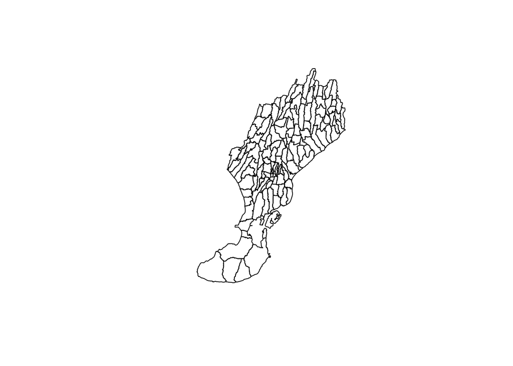

```r
# If needed, transform the polygon to match CRS between layers.
denpasar <- spTransform(x = denpasar, CRSobj = '+proj=moll +lon_0=0 +x_0=0 +y_0=0 +ellps=WGS84 +datum=WGS84 +units=m +no_defs')
plot(denpasar)
```

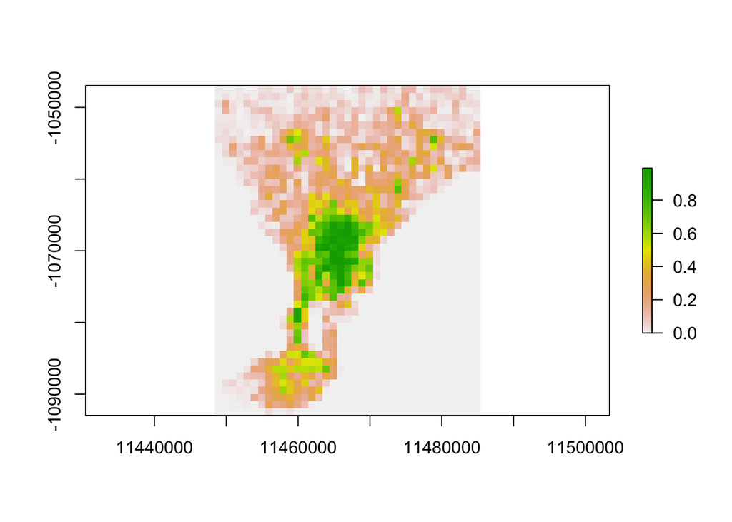

```r
plot(built_up)
```

## 3. Mask the raster

Once that the raster and the shapefile are in the same CRS, creating a mask is quite straightforward.

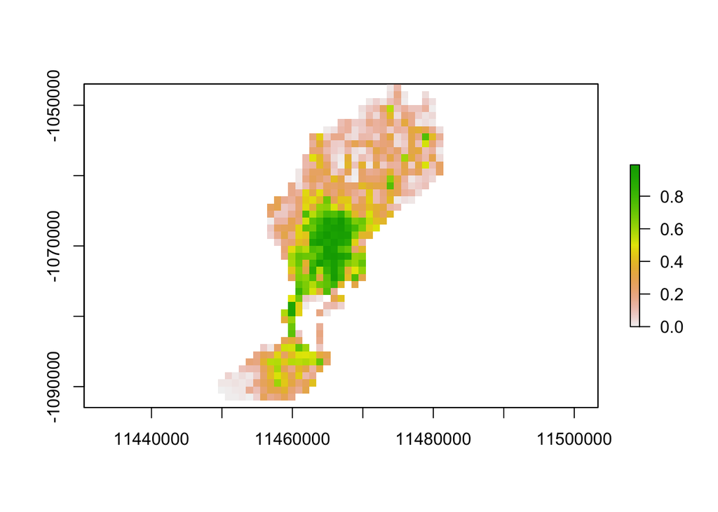

```r
masked <- mask(x = built_up, mask = denpasar)
plot(masked)
```

## 4. Crop the raster

As you can see from the figure below, the raster now has plenty of white space (cells with **NA** values). If that is your case, you might need to crop the raster. In this tutorial, we will use the shapefile extent to crop the raster.

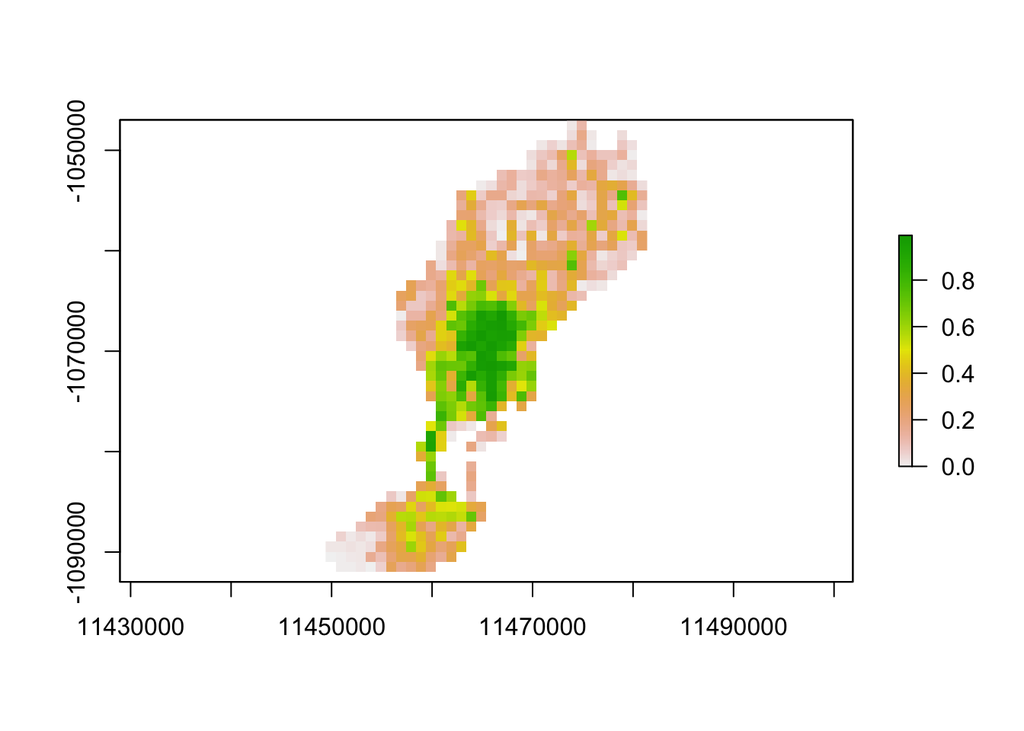

```r
cropped <- crop(x = masked, y = extent(denpasar))
plot(cropped)
```

## 5. Plot

Lastly, we will plot the final result using leaflet.

```r
pal <- colorNumeric(c("#556270", "#4ECDC4", "#C7F464", "#FF6B6B", "#C44D58"),
                    values(cropped),
                    na.color = "transparent")

leaflet() %>%
  addProviderTiles(providers$OpenStreetMap.BlackAndWhite) %>%
  addRasterImage(cropped, colors = pal, opacity = 0.5) %>%
  addLegend(pal = pal, values = values(cropped),
    title = "Built-up area")
```

[interactive chart not shown]

## 6. Save your raster file

Save your raster file in your preferred directory.

```r
writeRaster(cropped, filename = "_output/denpasar_builtup.tif", overwrite = TRUE)
```

That’s it!